# Open Peer Review

Jorge Vargas Centeno

# Reproducible research skills

## Open peer review of an article

[figure not shown]

For this project I’ll be testing my reproducible research skills reviewing the reproducibility and reporting practices of the article; [The COVID-19 Pandemic Eroded System Support but not Social Solidarity](https://pubmed.ncbi.nlm.nih.gov/37590308/)

[figure not shown]

Article: The COVID-19 Pandemic Eroded System Support but not Social Solidarity

### Project enviroment of the article

My chosen article have the following [project enviroment](https://osf.io/fwy5j/files/osfstorage):

[figure not shown]

Project enviroment of the article: the COVID-19 Pandemic Eroded System Support but not Social Solidarity

### Data structure:

With the given project enviroment we will obtain the following data structure:

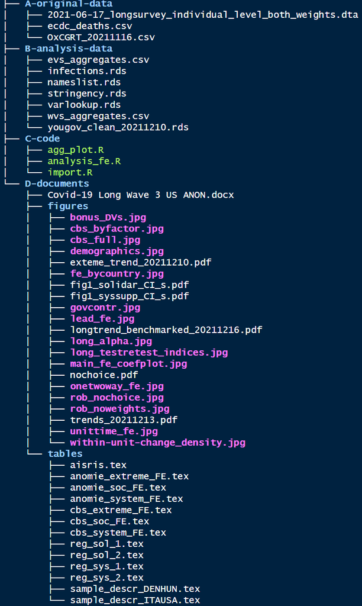

For the rest of this project I’ll be focusing in the R script *“agg_plot.R”* inside the folder **“C-code”**

## Impressions of the code

If we open the R script *“agg_plot.R”* we could find the following code:

```r
# a function to calculate quantile for a specific CI width
myquantile <- function(ci){
         alpha = (100-ci)/2/100
         qnorm(1-alpha)
}


# custom functions for calculating weighted mean and SE which work inside functions
mymean <- function(x,w) {wtd.mean(x = x, weights = w, na.rm  = T)}
myse <- function(x,w) {sqrt(wtd.var(x, weights = w, na.rm = T))/sqrt(length(x))}


# Import data -------------------------------------------------------------

df_full <- readRDS("B-analysis-data/yougov_clean_202204122.rds")
var_lookup <- readRDS("B-analysis-data/varlookup.rds")



# Figure 1. Benchmarked changes in Solidarity and System support ------------------------------
# ~ Crunch Systemic variables  -----------------------------------------------------

system_dvs <- c("system_satisfaction.z", "level_democracy.z", "supp_demcy.z",
                "proudcitizen.z")

# 4*3 country-wave means for individual outcomes
system_4c <- df_full %>%
        # subset to relevant vars for system support
        dplyr::select(country, weight, wavedate, all_of(system_dvs)) %>%
        # calculate weighted mean by country-waves
        pivot_longer(all_of(system_dvs), names_to = "dv") %>%
        group_by(country, wavedate, dv) %>%
        summarise(mean = mymean(value, weight),
                  se = myse(value, weight)) %>% glimpse

# reported in the text:
system_4c %>%
        group_by(country) %>%
        summarise(sum(mean > 0))

# reported in the text:
system_4c %>%
        filter(country %in% c("Denmark")) %>%
        filter(dv %in% c("level_democracy.z") &
                       wavedate == ymd("2020-12-12"))

# ---------------------A LOT MORE OF DATA WRANGLING AND ANALYSIS ------------------------

# ~ Draw system plot ---------------------------------------------------------
# ~ Panel A of Figure 1

system_facet <- ggplot(system_plotdata, aes( x =  wavedate, y = mean, color = dv)) +
        geom_rect(data = filter(system_plotdata, country == "Pooled"),
                  fill = NA, color = "black",
                  xmin = -Inf, xmax = Inf,
                  ymin = -Inf, ymax = Inf) +
        geom_hline(aes(yintercept = 0)) +
        geom_point(size = 1, alpha = .5) +
        geom_line(aes(group = dv), alpha = .7) +
        # add extra width to pooled lines
        geom_line(data = filter(system_plotdata,dv == "Pooled"), size = 1) +
        # add errorbars only to pooled estimates
        geom_errorbar(data = filter(system_plotdata,dv == "Pooled"),
                      aes(ymin = mean - myquantile(95)*se,
                          ymax = mean + myquantile(95)*se),
                      size = .6, width = 0) +
        xlab("") + ylab("") +
        scale_color_manual(name = NULL,
                           values = c("#000000", viridisLite::viridis(4)),
                              labels = c("Pooled",
                                         "\nLevel of \nDemocracy",
                                         "Proud Citizen",
                                         "\nSupport for \nDemocracy",
                                         "\nSatisf. with \nPol. System")
                              ) +
        scale_x_date(breaks = ymd(c("2020-04-20","2020-06-15","2020-12-12")),
                     limits = ymd(c("2020-04-01", "2020-12-31")),
                     date_labels = "%b") +
        ggtitle("System Support") +
        facet_grid(~country) +
        scale_y_continuous(limits = c(-1, .2)) +
        theme_minimal() +
        theme(panel.grid.minor = element_blank())

system_facet
```

```
## Rows: 48
## Columns: 5
## Groups: country, wavedate [12]
## $ country  <chr> "Denmark", "Denmark", "Denmark", "Denmark", "Denmark", "Denma…
## $ wavedate <date> 2020-04-20, 2020-04-20, 2020-04-20, 2020-04-20, 2020-06-15, …
## $ dv       <chr> "level_democracy.z", "proudcitizen.z", "supp_demcy.z", "syste…
## $ mean     <dbl> -0.69705093, -0.19933124, -0.21590985, -0.06795452, -0.793192…
## $ se       <dbl> 0.03401541, 0.02883877, 0.02366249, 0.02493922, 0.03692481, 0…
```

```
## # A tibble: 4 × 2
##   country `sum(mean > 0)`
##   <chr>             <int>
## 1 Denmark               0
## 2 Hungary               0
## 3 Italy                 1
## 4 USA                   2
```

```
## # A tibble: 1 × 5
## # Groups:   country, wavedate [1]
##   country wavedate   dv                  mean     se
##   <chr>   <date>     <chr>              <dbl>  <dbl>
## 1 Denmark 2020-12-12 level_democracy.z -0.916 0.0428
```

```
## Rows: 12
## Columns: 5
## Groups: country [4]
## $ country  <chr> "Denmark", "Denmark", "Denmark", "Hungary", "Hungary", "Hunga…
## $ wavedate <date> 2020-04-20, 2020-06-15, 2020-12-12, 2020-04-20, 2020-06-15, …
## $ mean     <dbl> -0.2950616, -0.3615610, -0.4304080, -0.3466159, -0.3783803, -…
## $ se       <dbl> 0.01440347, 0.01583371, 0.01736561, 0.01285579, 0.01680848, 0…
## $ dv       <chr> "Pooled", "Pooled", "Pooled", "Pooled", "Pooled", "Pooled", "…
```

```
## Rows: 12
## Columns: 5
## Groups: wavedate [3]
## $ wavedate <date> 2020-04-20, 2020-04-20, 2020-04-20, 2020-04-20, 2020-06-15, …
## $ dv       <chr> "level_democracy.z", "proudcitizen.z", "supp_demcy.z", "syste…
## $ mean     <dbl> -0.49391135, -0.18197042, -0.26015389, -0.08754136, -0.559581…
## $ se       <dbl> 0.01516400, 0.01477147, 0.01109283, 0.01313228, 0.01781351, 0…
## $ country  <chr> "Pooled", "Pooled", "Pooled", "Pooled", "Pooled", "Pooled", "…
```

```
## Rows: 3
## Columns: 5
## $ wavedate <date> 2020-04-20, 2020-06-15, 2020-12-12
## $ mean     <dbl> -0.2558943, -0.3181518, -0.3712863
## $ se       <dbl> 0.006884393, 0.008026691, 0.008694820
## $ country  <chr> "Pooled", "Pooled", "Pooled"
## $ dv       <chr> "Pooled", "Pooled", "Pooled"
```

```
## # A tibble: 3 × 5
##   wavedate    mean      se country dv
##   <date>     <dbl>   <dbl> <chr>   <chr>
## 1 2020-04-20 -0.26 0.00688 Pooled  Pooled
## 2 2020-06-15 -0.32 0.00803 Pooled  Pooled
## 3 2020-12-12 -0.37 0.00869 Pooled  Pooled
```

### Readibility

After seeing this code my first impressions are:

1. This code is a combination of various data wrangling and analysis steps, *including custom functions to streamline the workflow for this project.* These various step are needed to plot the various plots inside the code and article.
2. The code is really well documented. It has a lot of comments indicating what is the function of each chunk code inside code. This make more easy to understand what does the code do.
3. The name of each variable and object makes sense. They don’t have a random name, which makes easier to understand what is inside of object/list.

#### Readibility score

Thus, due to the previous points, I’ll be giving to this article a readibility score of **5 stars**

[figure not shown]

### Reproducibility

To rate the reproducibility of this article, I will try to reproduce the first plot in the R script *“agg_plot.R”*. I will try to reproduce the the next code:

```r
# ~ Draw system plot ---------------------------------------------------------
# ~ Panel A of Figure 1

system_facet <- ggplot(system_plotdata, aes( x =  wavedate, y = mean, color = dv)) +
        geom_rect(data = filter(system_plotdata, country == "Pooled"),
                  fill = NA, color = "black",
                  xmin = -Inf, xmax = Inf,
                  ymin = -Inf, ymax = Inf) +
        geom_hline(aes(yintercept = 0)) +
        geom_point(size = 1, alpha = .5) +
        geom_line(aes(group = dv), alpha = .7) +
        # add extra width to pooled lines
        geom_line(data = filter(system_plotdata,dv == "Pooled"), size = 1) +
        # add errorbars only to pooled estimates
        geom_errorbar(data = filter(system_plotdata,dv == "Pooled"),
                      aes(ymin = mean - myquantile(95)*se,
                          ymax = mean + myquantile(95)*se),
                      size = .6, width = 0) +
        xlab("") + ylab("") +
        scale_color_manual(name = NULL,
                           values = c("#000000", viridisLite::viridis(4)),
                              labels = c("Pooled",
                                         "\nLevel of \nDemocracy",
                                         "Proud Citizen",
                                         "\nSupport for \nDemocracy",
                                         "\nSatisf. with \nPol. System")
                              ) +
        scale_x_date(breaks = ymd(c("2020-04-20","2020-06-15","2020-12-12")),
                     limits = ymd(c("2020-04-01", "2020-12-31")),
                     date_labels = "%b") +
        ggtitle("System Support") +
        facet_grid(~country) +
        scale_y_continuous(limits = c(-1, .2)) +
        theme_minimal() +
        theme(panel.grid.minor = element_blank())

system_facet
```

#### Issues

The first issue that I encounter to reproduce this code had something to do with the importing of the data.

```r
# Import data -------------------------------------------------------------

df_full <- readRDS("B-analysis-data/yougov_clean_202204122.rds")
var_lookup <- readRDS("B-analysis-data/varlookup.rds")
```

There are two main issues with this code:

1. The first one is a very common issue. Obviously the data/folder structure of the original project differs with my data/folder structure. For this reason the needed file cannot been found in my computer directory
2. The second one has something to do with the name of the files. The file name **yougov_clean_202204122.rds** differs with the file name in the folder **B-analysis-data**. The file name in this folder **yougov_clean_20211210.rds**.

We can resolve this issue modifing the previous code as follow:

```r
# Import data -------------------------------------------------------------

df_full <- readRDS(here("projects", "review", "B-analysis-data", "yougov_clean_20211210.rds"))
var_lookup <- readRDS(here("projects", "review", "B-analysis-data", "varlookup.rds"))
```

#### Plot

After resolving this previous issues we can reproduce the next figure:

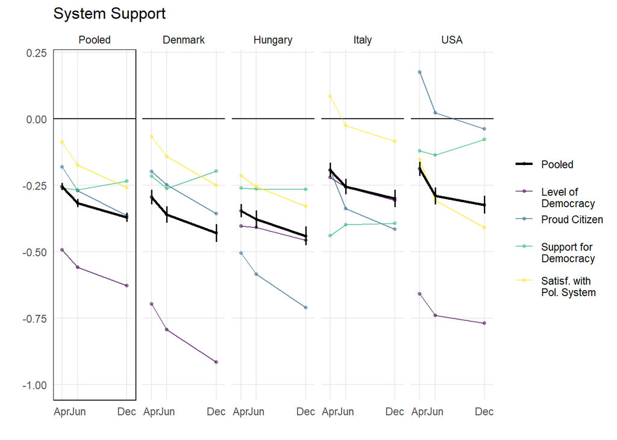

```r
# ~ Draw system plot ---------------------------------------------------------
# ~ Panel A of Figure 1

system_facet <- ggplot(system_plotdata, aes( x =  wavedate, y = mean, color = dv)) +
        geom_rect(data = filter(system_plotdata, country == "Pooled"),
                  fill = NA, color = "black",
                  xmin = -Inf, xmax = Inf,
                  ymin = -Inf, ymax = Inf) +
        geom_hline(aes(yintercept = 0)) +
        geom_point(size = 1, alpha = .5) +
        geom_line(aes(group = dv), alpha = .7) +
        # add extra width to pooled lines
        geom_line(data = filter(system_plotdata,dv == "Pooled"), size = 1) +
        # add errorbars only to pooled estimates
        geom_errorbar(data = filter(system_plotdata,dv == "Pooled"),
                      aes(ymin = mean - myquantile(95)*se,
                          ymax = mean + myquantile(95)*se),
                      size = .6, width = 0) +
        xlab("") + ylab("") +
        scale_color_manual(name = NULL,
                           values = c("#000000", viridisLite::viridis(4)),
                              labels = c("Pooled",
                                         "\nLevel of \nDemocracy",
                                         "Proud Citizen",
                                         "\nSupport for \nDemocracy",
                                         "\nSatisf. with \nPol. System")
                              ) +
        scale_x_date(breaks = ymd(c("2020-04-20","2020-06-15","2020-12-12")),
                     limits = ymd(c("2020-04-01", "2020-12-31")),
                     date_labels = "%b") +
        ggtitle("System Support") +
        facet_grid(~country) +
        scale_y_continuous(limits = c(-1, .2)) +
        theme_minimal() +
        theme(panel.grid.minor = element_blank())
system_facet
```

#### Reproducibility score

Thus, due to the previous points, I’ll be giving to this article a reproducibilityscore of **4.5 stars**

[figure not shown]